# Analyse des avis scrapped du site monavislerendsgratuit

Le jeu de données a été extrait du site monavislerendsgratuit à l'aide du framework scrapy. Le code permettant l'extraction peut être trouvée ici : https://github.com/Mg30/ScrapyCrawlerConsumerReviews

## Aperçu du jeu de données

```python
df.head()
```

|  | comment | consummer_rate | date | product_avg_rate | product_name | user_info | username |
| --- | --- | --- | --- | --- | --- | --- | --- |
| 0 | On ne sent pas tellement le citron | 3 | 3 Octobre 2019 | 4.16275 | San Pellegrino Limone + Tea ou Pesca + Tea | [\n\t\t\t\t\t\tSaint-andré-lez-lille, 43 ans\t... | Virgil C |
| 1 | Super bon surtout quand il est au frais | 5 | 4 Octobre 2019 | 4.16275 | San Pellegrino Limone + Tea ou Pesca + Tea | [\n\t\t\t\t\t\tNanterre, 41 ans\t\t\t\t\t, Ave... | Saleha M |
| 2 | Très bien | 5 | 17 Octobre 2019 | 4.16275 | San Pellegrino Limone + Tea ou Pesca + Tea | [\n\t\t\t\t\t\tLe plessis trevise, 37 ans\t\t\... | Mendes K |
| 3 | Très bonne boisson the citron | 5 | 4 Octobre 2019 | 4.16275 | San Pellegrino Limone + Tea ou Pesca + Tea | [\n\t\t\t\t\t\tGermigny, 42 ans\t\t\t\t\t] | Valerie C |
| 4 | Trop bon et trop petit on y retourne | 5 | 3 Octobre 2019 | 4.16275 | San Pellegrino Limone + Tea ou Pesca + Tea | [\n\t\t\t\t\t\tMonaco, 52 ans\t\t\t\t\t, Avec ... | Elena G |

```python
df.info()
```

```
<class 'pandas.core.frame.DataFrame'>
RangeIndex: 620 entries, 0 to 619
Data columns (total 7 columns):
comment             620 non-null object
consummer_rate      620 non-null object
date                620 non-null object
product_avg_rate    620 non-null object
product_name        620 non-null object
user_info           620 non-null object
username            620 non-null object
dtypes: object(7)
memory usage: 34.0+ KB
```

Le jeu de données a un volume de 620 observations et 7 variables, on peut voir également que toutes les variables sont de types object, ce qui suggère qu'un travail de nettoyage va devoir être réalisé

## Nettoyage du fichier

L'objectif de cette étape est de rendre le jeu de données plus propre en vue de son analyse

### Traitement de la variable user_info

```python
df["user_info"].head()
```

```
0    [\n\t\t\t\t\t\tSaint-andré-lez-lille, 43 ans\t...
1    [\n\t\t\t\t\t\tNanterre, 41 ans\t\t\t\t\t, Ave...
2    [\n\t\t\t\t\t\tLe plessis trevise, 37 ans\t\t\...
3           [\n\t\t\t\t\t\tGermigny, 42 ans\t\t\t\t\t]
4    [\n\t\t\t\t\t\tMonaco, 52 ans\t\t\t\t\t, Avec ...
Name: user_info, dtype: object
```

On peut voir que la variable user_info regroupe plusieurs informations dans une structure de données de type list, l'objectif est de séparer les différentes informations dans des variables séparées

#### Récupération des informations relatives à la présence d'enfant ou non

Les personnes s'enregistrant sur le site peuvent renseigner un champs "avec enfant(s)", on considérera que les personnes n'ayant pas renseigné ce champs n'ont pas d'enfants. Cette aproche peut être biaisé car certaines personnes ayant des enfants peuvent ne pas avoir renseigné le champs.

```python
def parse_enfant_from(user_info):
    if len(user_info) == 2:
        return 1
    else:
        return 0
```

```python
df["enfant"] = df["user_info"].apply(parse_enfant_from)
```

#### Récupération des informations relatives à l'age

```python
def parse_age_from(user_info):
    if user_info:
        age = user_info[0].split(',')[-1]
        age = int(age[:3])
        return age
```

```python
df["age"] = df["user_info"].apply(parse_age_from)
```

#### Récupération du lieu d'habitation

```python
def parse_loc_from(user_info):
    if user_info:
        loc = user_info[0].split(',')[0].replace('\t', '').replace('\n', '')
        return loc
```

```python
df["localisation"] = df["user_info"].apply(parse_loc_from)
```

### Traitement de la variable consummer_rate

La varibale consumer_rate représente la note attribuée au produit par le consommateur, dans le dataframe elle est de type d'object alors qu'elle devrait être de type float. Il faut donc la convertir

```python
df["consummer_rate"] = df["consummer_rate"].astype(float)
```

### Traitement de la varibale date

```python
def parse_date(date):
    import locale
    locale.setlocale(locale.LC_ALL, 'fr_FR')
    date_splited = date.split(' ')
    day = date_splited[0]
    year = date_splited[-1]
    month = date_splited[-2]
    if len(day) == 1:
        day = f'0{day}'
    return  f"{day} {month} {year}"
```

```python
df["date"] = df["date"].apply(parse_date)
df["date"] = pd.to_datetime(df["date"], format="%d %B %Y")
```

```python
df["day_week_number"] = df["date"].apply(lambda date: pendulum.instance(date).day_of_week)
```

```python
df["date"] = df["date"].dt.date
```

### Traitement du username

```python
def reformat(username):
    if username:
        return username[:-2]
```

```python
df["username"] = df["username"].apply(reformat)
```

### Suppression des variables inutiles

Désormais, il est possible de supprimer les variables suivantes :

- product_name, car la variable n'apporte pas de plus value
- user_info car la variable a été traitée et les informations qu'elle contient on été divisées

```python
df = df.drop(columns=["user_info", "product_name"])
```

### Résultat de la transformation

```python
df.head()
```

|  | comment | consummer_rate | date | product_avg_rate | username | enfant | age | localisation | day_week_number |
| --- | --- | --- | --- | --- | --- | --- | --- | --- | --- |
| 0 | On ne sent pas tellement le citron | 3.0 | 2019-10-03 | 4.16275 | Virgil | 1 | 43 | Saint-andré-lez-lille | 4 |
| 1 | Super bon surtout quand il est au frais | 5.0 | 2019-10-04 | 4.16275 | Saleha | 1 | 41 | Nanterre | 5 |
| 2 | Très bien | 5.0 | 2019-10-17 | 4.16275 | Mendes | 1 | 37 | Le plessis trevise | 4 |
| 3 | Très bonne boisson the citron | 5.0 | 2019-10-04 | 4.16275 | Valerie | 0 | 42 | Germigny | 5 |
| 4 | Trop bon et trop petit on y retourne | 5.0 | 2019-10-03 | 4.16275 | Elena | 1 | 52 | Monaco | 4 |

## Enrichissement du jeu de données

L'objectif de cette étape est de voir à partir des variables présentent dans le jeu de données quelles autres informations il est possible d'extraire à partir du jeu de données ou en faisant appel à des services externes

### Ajout d'une variable indiquant la taille de chaque commentaire

Il est intéréssant d'avoir la taille des commentaires, puisqu'il est possible que la taille d'un commentaire soit corrélée à la note attribuée. La taille d'un commentaire sera ici considérée comme le nombre de mots qui le compose.

```python
df["len_comment"] = df["comment"].apply(lambda x: len(x.split(" ")))
```

### Ajout region à partir de la ville

Pour obtenir la région à partir de la ville présente dans la variable localisation, il a été utilisé l'api https://api.gouv.fr/api/api-geo.

```python
df_region.head()
```

|  | commune | region |
| --- | --- | --- |
| 0 | Saint-André-lez-Lille | Hauts-de-France |
| 1 | Nanterre | Île-de-France |
| 2 | Le Plessis-Trévise | Île-de-France |
| 3 | Germigny | Grand Est |
| 4 | Cagny | Normandie |

```python
df = df.merge(df_region,left_on='localisation',right_on='commune').drop(columns=['localisation'])
```

### Ajout genre à partir des noms

Pour déterminer le genre à partir du nom, il a été utilisé le site https://gender-api.com

```python
df = df.merge(df_genre,left_on="username", right_on="Nom")
```

```python
df.head()
```

|  | comment | consummer_rate | date | product_avg_rate | username | enfant | age | day_week_number | len_comment | commune | region | ga_gender |
| --- | --- | --- | --- | --- | --- | --- | --- | --- | --- | --- | --- | --- |
| 0 | Super bon surtout quand il est au frais | 5.0 | 2019-10-04 | 4.16275 | Saleha | 1 | 41 | 5 | 8 | Nanterre | Île-de-France | female |
| 1 | Boisson fraiche aromatisée, idéale pour l'été ... | 4.0 | 2019-09-19 | 4.16275 | Aurelie | 1 | 36 | 4 | 32 | Nanterre | Île-de-France | female |
| 2 | bon produit | 4.0 | 2019-09-23 | 4.16275 | Aurelie | 0 | 25 | 1 | 2 | Meloisey | Bourgogne-Franche-Comté | female |
| 3 | Je n ai pas aimer ce produit | 2.0 | 2019-09-24 | 4.16275 | Aurelie | 1 | 41 | 2 | 7 | Mardeuil | Grand Est | female |
| 4 | Très bonne boisson the citron | 5.0 | 2019-10-04 | 4.16275 | Valerie | 0 | 42 | 5 | 5 | Germigny | Grand Est | female |

### Ajout d'une variable indiquant si le commentaire est positif

On considérera que tous les commentaires qui sont en dessous de 3 sont négatifs et les autres possitifs

```python
def is_positiv(consummer_rate):
    if consummer_rate < 3:
        return 0
    else:
        return 1
```

```python
df["is_positiv"] = df["consummer_rate"].apply(is_positiv)
```

## Analyses univariées

### Analyse de la variable enfant

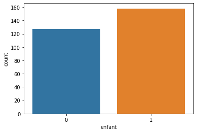

```python
sns.countplot(x="enfant",data=df)
```

Comme on peut le voir la majorité des personnes ayant commentées ont déclaré avoir un ou plusieurs enfants

### Analyse de l'age

#### Analyse de la distribution

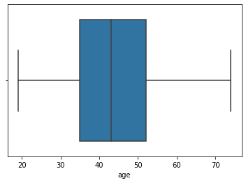

```python
sns.boxplot(df["age"])
```

#### Analyse des outliers

```python
df[df["age"] > 72]
```

[output not shown]

Il aurait été possible de suspecter pour ces outliers, des personnes renseignant une date de naissance fictive. Toutefois le détails des outliers montrent qu'il ne s'agit pas de données aberrantes.

### Analyse de la variable date

#### Analyse de la distribution

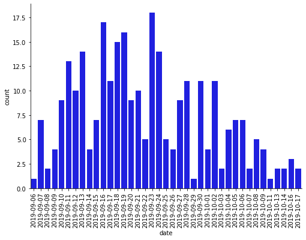

```python
groupby_date = df.groupby(by='date').describe()['age'].reset_index()
chart = sns.catplot(x='date',y='count',data= groupby_date, aspect=1.5, kind="bar", color="b")
chart.set_xticklabels(rotation=90)
```

On peut observer une certaine saisonnalité dans la distribution des données, on peut voir que il y a des jours qui sont priviligés pour commenter qui peut correspondre au jour où les personnes ont fait leur courses. Analysons maintenant les données par position du jour dans la semaine.

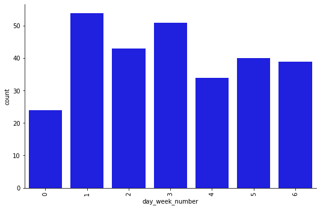

```python
groupby_date = df.groupby(by='day_week_number').describe()['age'].reset_index()
chart = sns.catplot(x='day_week_number',y='count',data= groupby_date, aspect=1.5, kind="bar", color="b")
chart.set_xticklabels(rotation=90)
```

### Analyse de la variable consummer_rate

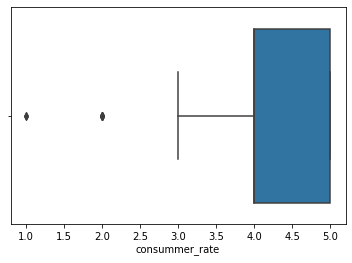

```python
sns.boxplot(df["consummer_rate"])
```

On peut voir qu'il y a des outliers, il convient d'analyser les données en dessous de 3.0

#### Analyse des outliers

```python
outliers = df["comment"][df["consummer_rate"] < 3]
outliers
```

[output not shown]

On peut voir que les outliers ne représentent pas des données abérantes, elles seront donc gardées dans l'analyse postérieure

### Analyse de la longueur des commentaires

```python
df["len_comment"].describe()
```

```
count    285.000000
mean       9.045614
std        7.716456
min        1.000000
25%        4.000000
50%        7.000000
75%       12.000000
max       46.000000
Name: len_comment, dtype: float64
```

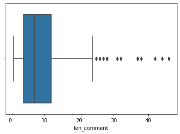

```python
sns.boxplot(df["len_comment"])
```

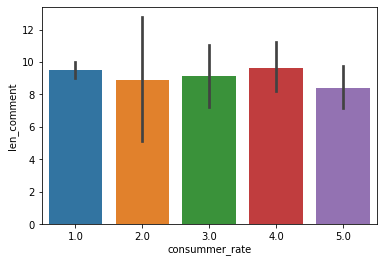

```python
sns.barplot(x='consummer_rate', y='len_comment',data=df)
```

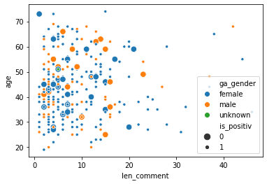

```python
sns.scatterplot(x='len_comment', y='age', hue='ga_gender',size='is_positiv',data=df)
```

On peut constater que la majorité des commentaires sont assez courts et ce peu importe la note attribué par l'utilisateur ou son age.

### Analyse de la localisation

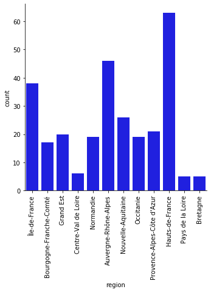

```python
chart = sns.catplot(x='region',data= df, kind="count", color="b")
chart.set_xticklabels(rotation=90)
```

On peut voir que la majorité des commentaires viennent de personnes habitant dans les régions Hauts-de-France suivi par la région Auvergne Rhones Alpes puis l'île de france.

### Analyse des genres

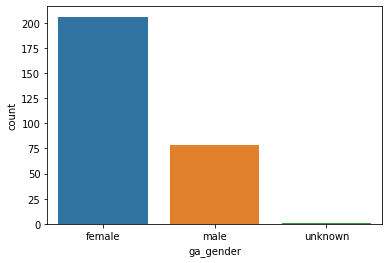

```python
sns.countplot(df["ga_gender"])
```

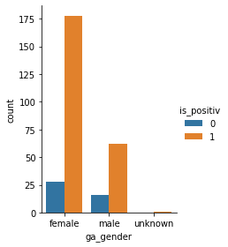

```python
g = sns.catplot(x="ga_gender", hue="is_positiv",
                data=df, kind="count",
                height=4, aspect=.7);
```

On constate que la majorité des personnes qui ont commenté sont de sexe feminin. Toutefois on peut voir que le sexe de la personne ne semble pas influencer la possitivité du commentaire.

### Analyse des commentaires négatif

```python
text = " ".join(
    review for review in df.comment[df["is_positiv"]==0])
```

#### Génération d'un nuage de mots

[figure not shown]

```python
wordcloud = WordCloud(
    stopwords=stopwords, background_color="white", max_words=30).generate(text)
plt.imshow(wordcloud, interpolation="bilinear")
plt.axis("off")
plt.show()
```

Le nuage de mots ne renseigne pas sur les éventuels problèmes que peut avoir le produit. Bien que ce dernier ait une note de 4.1 en moyenne ce qui est élévée. Pour en savoir d'avantage, un nuage de mots bigrammes pourrait permettre d'en apprendre d'avantage sur les possibles améliorations à apporter au produit.

#### Génération d'un nuage de mots bigramms

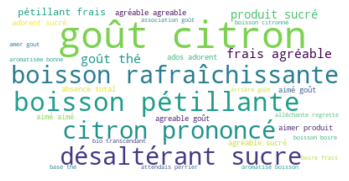

```python
wordcloud_bigrams = WordCloud( stopwords=stopwords,background_color="white", max_words=30)
wordcloud_bigrams.generate_from_frequencies(frequencies=freq)
plt.imshow(wordcloud_bigrams, interpolation="bilinear")
plt.axis("off")
plt.show()
```

On peut voir que le nuage fait ressortir des choses plutôt possitive. Toutefois on peut noter que la boisson est considérée comme sucrée. Enfin on note également que le goût citron peut être trop prononcé.

## Analyse bivariées

### Identification des variables qui sont corrélées

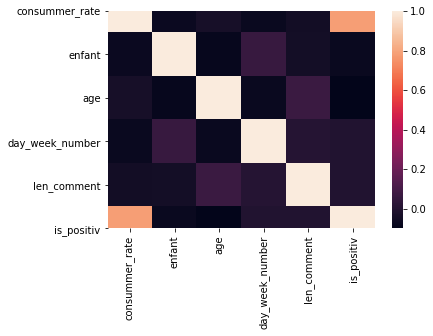

```python
sns.heatmap(df.corr())
```

On peut voir que la seule correlation, entre consummer_rate et is_possitiv n'est pas significative car il s'agit d'une corrélation qui a été crée dans une des étapes précédentes.